# Coding Assignment 1

Group 16

Due: 2023-10-01 23:59

```r
# Put any packages you want here
```

A Florida health insurance company wants to predict annual claims for individual clients. The company pulls a random sample of 100 customers. The owner wishes to charge an actuarially fair premium to ensure a normal rate of return. The owner collects all of their current customer’s health care expenses from the last year and compares them with what is known about each customer’s plan.

The data on the 100 customers in the sample is as follows:

- Charges: Total medical expenses for a particular insurance plan (in dollars)
- Age: Age of the primary beneficiary
- BMI: Primary beneficiary’s body mass index (kg/m2)
- Female: Primary beneficiary’s birth sex (0 = Male, 1 = Female)
- Children: Number of children covered by health insurance plan (includes other dependents as well)
- Smoker: Indicator if primary beneficiary is a smoker (0 = non-smoker, 1 = smoker)
- Cities: Dummy variables for each city with the default being Sanford

Answer the following questions using complete sentences and attach all output, plots, etc. within this report.

**For this assignment, ignore the categorical variables (gender, smoker, cities)**

# Question 1

Perform univariate analyses on the quantitative variables (center, shape, spread). Include descriptive statistics, and histograms. Be sure to use terms discussed in class such as bimodal, skewed left, etc.

```r
summary(Insurance_Data_Group16)
```

```
##     Charges           Age            BMI           Children
##  Min.   : 1256   Min.   :18.0   Min.   :17.67   Min.   :0.00
##  1st Qu.: 5842   1st Qu.:30.5   1st Qu.:26.32   1st Qu.:0.00
##  Median : 8825   Median :42.0   Median :30.08   Median :1.00
##  Mean   :13819   Mean   :41.6   Mean   :30.73   Mean   :1.03
##  3rd Qu.:18278   3rd Qu.:54.0   3rd Qu.:33.78   3rd Qu.:2.00
##  Max.   :47928   Max.   :64.0   Max.   :47.60   Max.   :5.00
```

```r
#Mean, Median, Range, SD, IQR
Insurance_Data_Group16 %>%
tbl_summary(statistic=list(all_continuous() ~ c("{mean} ({sd})",
"{median} ({p25}, {p75})",
"{min}, {max}"),
all_categorical() ~ "{n} / {N} ({p}%)"),
type=all_continuous() ~ "continuous2"
)
```

| **Characteristic** | **N = 100**<sup>1</sup> |
| --- | --- |
| Charges |  |
| Mean (SD) | 13,819 (12,359) |
| Median (IQR) | 8,825 (5,842, 18,278) |
| Range | 1,256, 47,928 |
| Age |  |
| Mean (SD) | 42 (14) |
| Median (IQR) | 42 (31, 54) |
| Range | 18, 64 |
| BMI |  |
| Mean (SD) | 31 (6) |
| Median (IQR) | 30 (26, 34) |
| Range | 18, 48 |
| Children |  |
| 0 | 48 / 100 (48%) |
| 1 | 18 / 100 (18%) |
| 2 | 21 / 100 (21%) |
| 3 | 11 / 100 (11%) |
| 5 | 2 / 100 (2.0%) |

<sup>1</sup> n / N (%)

**Charges:**

The mean Charge is $13,819 and the median is $8,825, suggesting the data is skewed right or postively skewed. The data is unimodal. The range of the Charges is from $1,256 to $47,928. The interquartile range (IQR) is from $5,842 to $18,278.

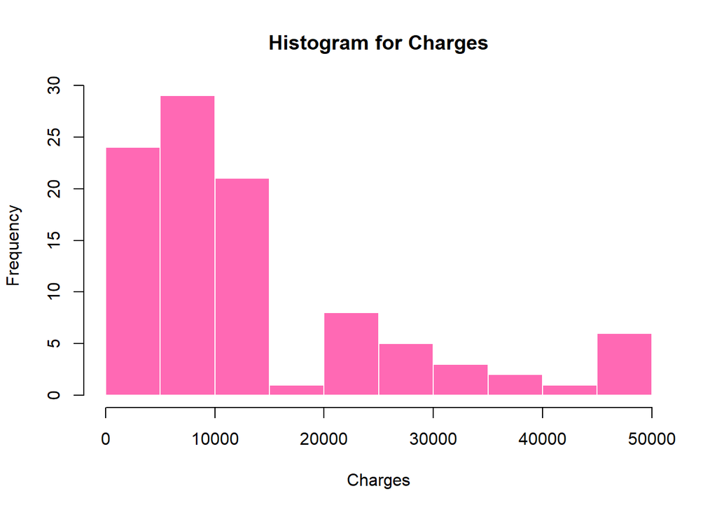

```r
hist(Insurance_Data_Group16$Charges, main="Histogram for Charges", xlab="Charges", ylab="Frequency", col="hotpink", border="white")
```

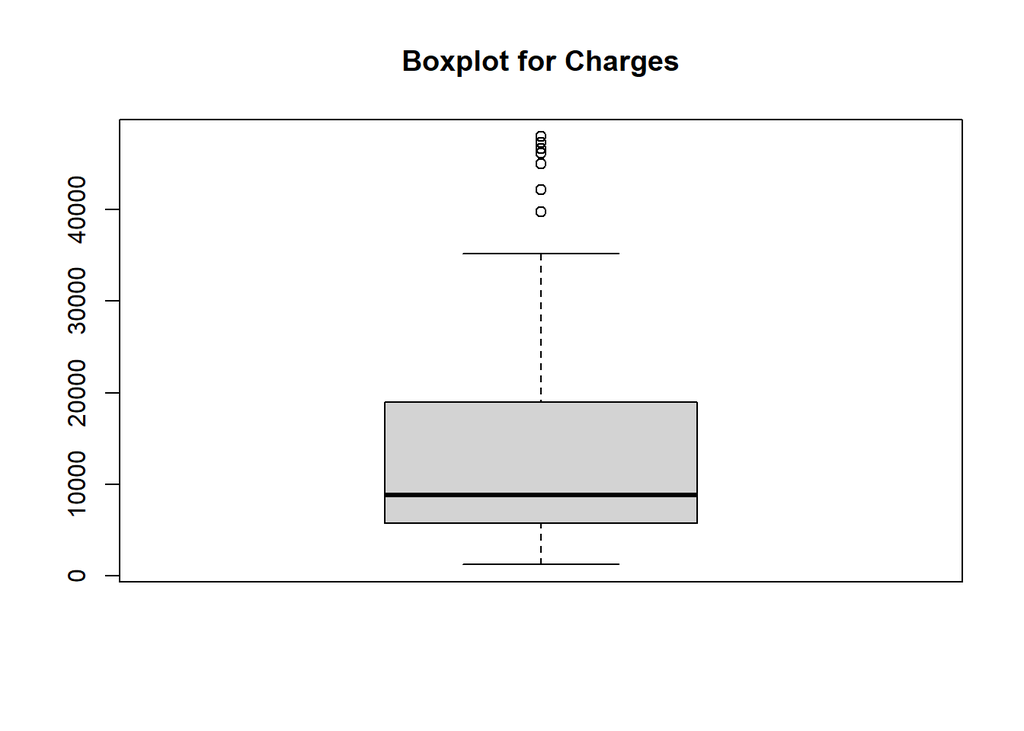

```r
boxplot(Insurance_Data_Group16$Charges, main="Boxplot for Charges")
```

**Age:**

The average Age is 41.6 years, and the median Age is 42 years. The mean and median are very close, suggesting a relatively symmetrical distribution. The data is multimodal. The Age ranges from 18 to 64 years. The IQR is from 30.5 to 54 years.

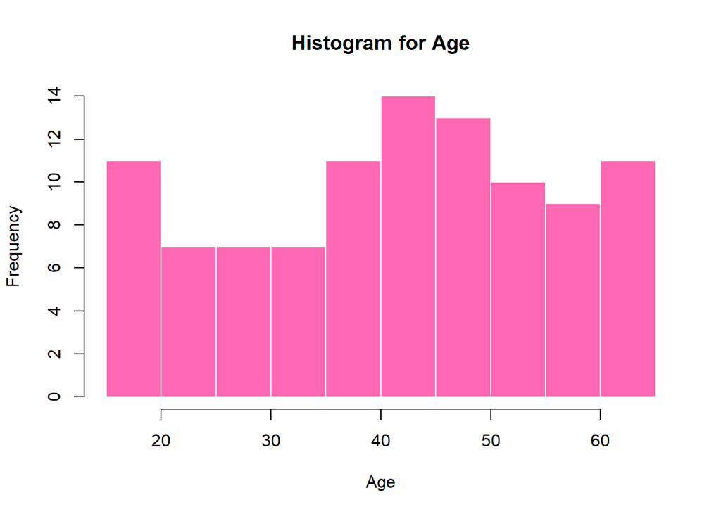

```r
hist(Insurance_Data_Group16$Age, main="Histogram for Age", xlab="Age", ylab="Frequency", col="hotpink", border="white")
```

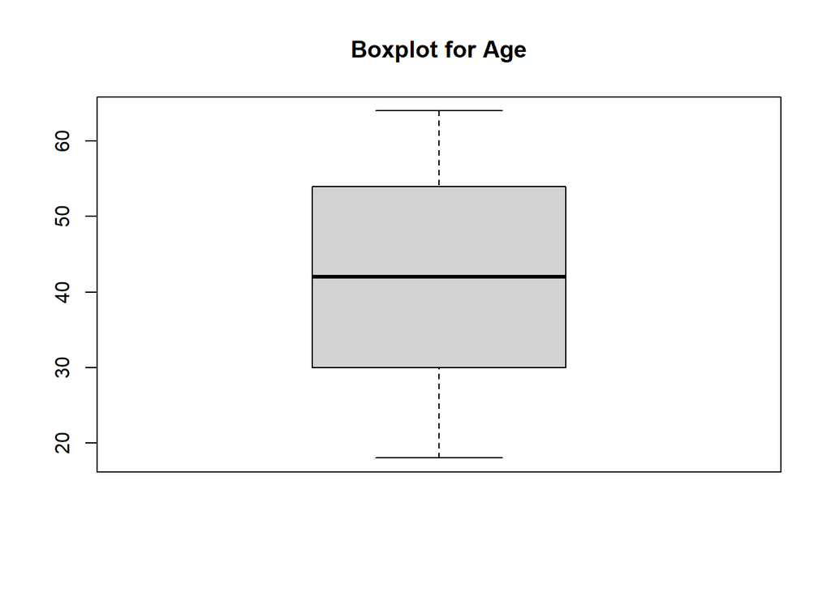

```r
boxplot(Insurance_Data_Group16$Age, main="Boxplot for Age")
```

**BMI:**

The mean BMI is 30.73, and the median BMI is 30.08. The mean is slightly higher than the median and distribution is symmetrical. The data is unimodal. The BMI values range from 17.67 to 47.60. The IQR is from 26.32 to 33.78.

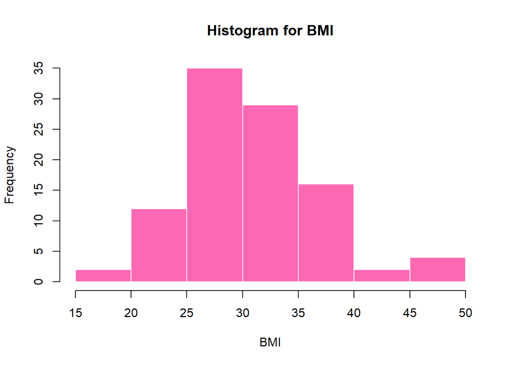

```r
hist(Insurance_Data_Group16$BMI, main="Histogram for BMI", xlab="BMI", ylab="Frequency", col="hotpink", border="white")
```

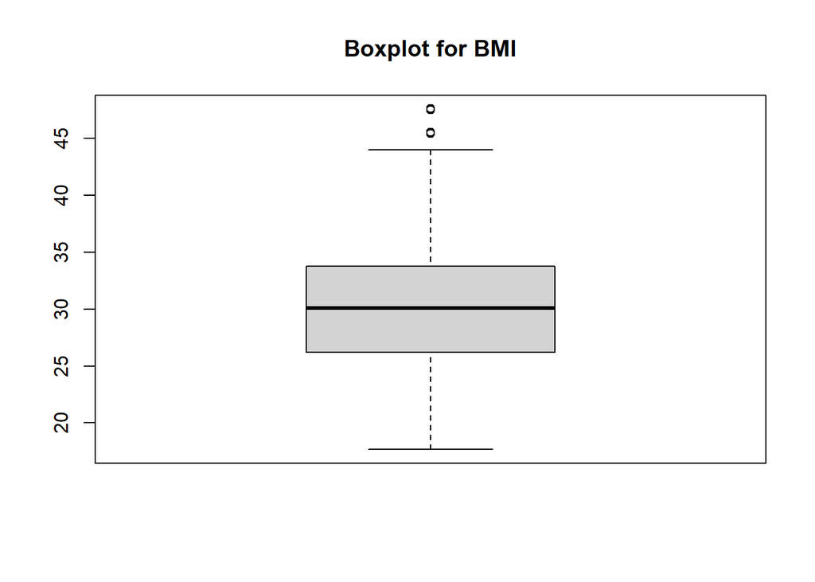

```r
boxplot(Insurance_Data_Group16$BMI, main="Boxplot for BMI")
```

**Children**:

On average, individuals in the dataset have approximately 1.03 Children, with a median of 1 Child. The data is skewed right and bimodal. The number of Children varies from 0 to 5. The IQR is from 0 to 2 Children.

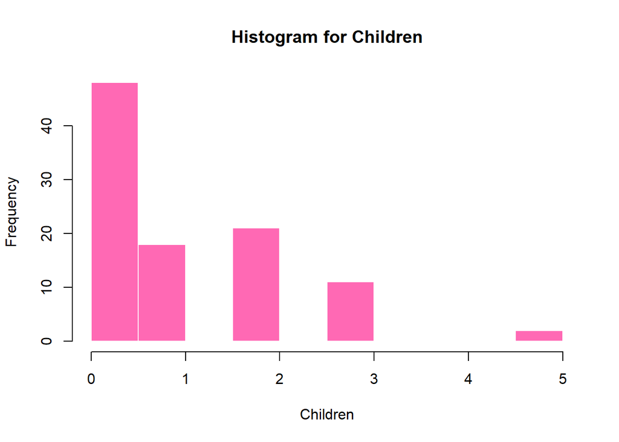

```r
hist(Insurance_Data_Group16$Children, main="Histogram for Children", xlab="Children", ylab="Frequency", col="hotpink", border="white")
```

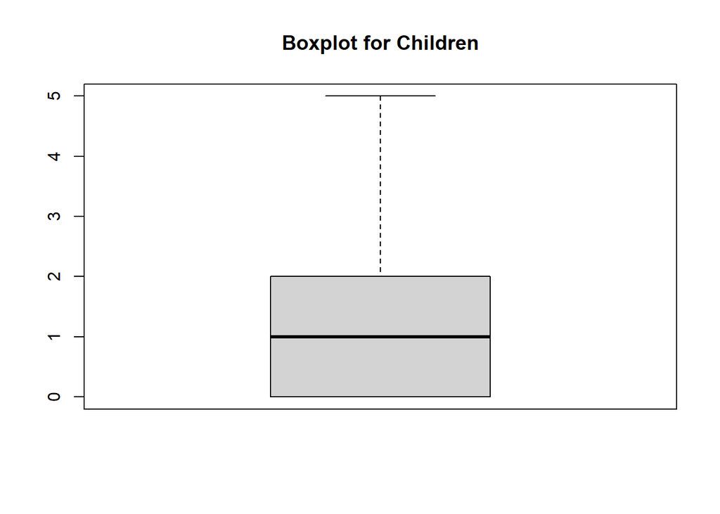

```r
boxplot(Insurance_Data_Group16$Children, main="Boxplot for Children")
```

# Question 2

Perform bivariate analyses on the quantitative variables (direction, strength and form). Describe the linear association between all variables.

There is a weak linear correlation between the following variables:

BMI and Children: -.02

Charges and Children and Charges and BMI: .09 and .21 respectively

Age and Children and Age and BMI: -.07 and .09 respectively

There is a stronger liner correlation between Age and Charges, but the correlation still would be considered weak with a correlation of .42. All number are closer to zero than (-1,1) and would all display weak linear correlations.

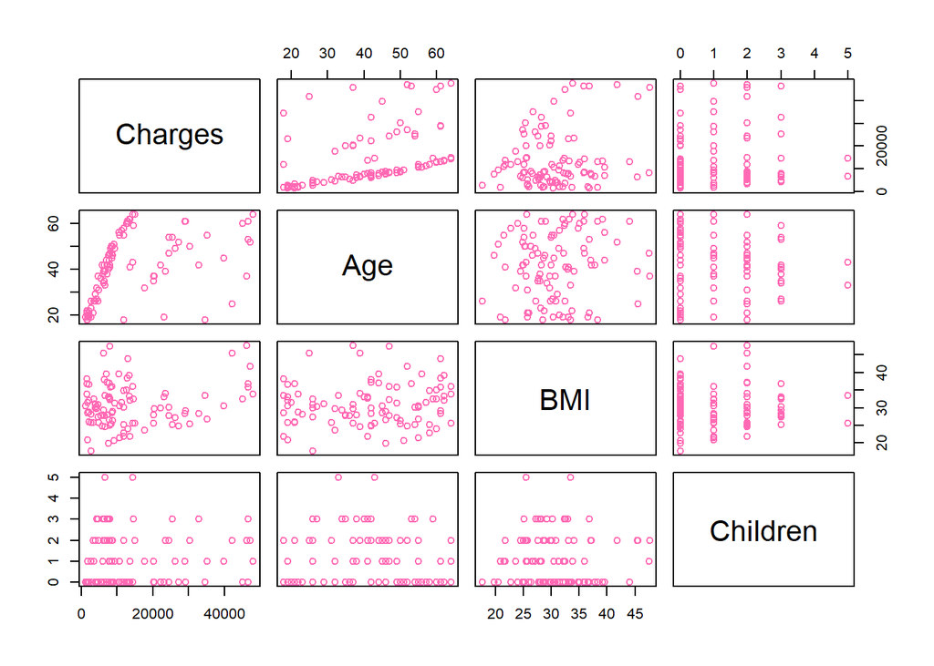

```r
#Distribution and relationships of each variable
pairs(Insurance_Data_Group16, col="hotpink")
```

```r
#Correlation
#Correlation between Charges and Children
cor(Insurance_Data_Group16$Charges, Insurance_Data_Group16$Children)
```

```
## [1] 0.08724211
```

```r
corrplot(cor(Insurance_Data_Group16),
type="lower",
order="hclust",
tl.col="black",
tl.srt=45,
addCoef.col = "black",
diag=FALSE)

#Correlation between Age and BMI
cor(Insurance_Data_Group16$Age, Insurance_Data_Group16$BMI)
```

[output not shown]

```
## [1] 0.09387806
```

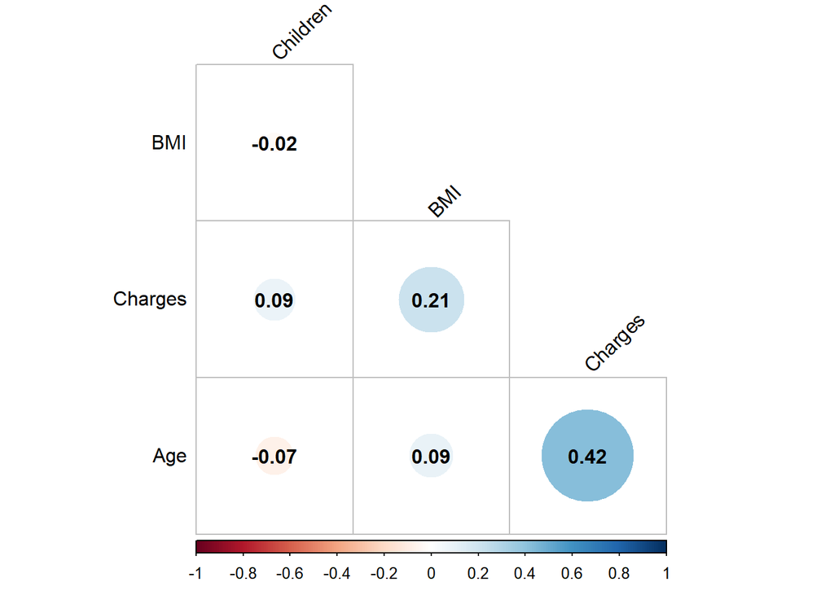

```r
corrplot(cor(Insurance_Data_Group16),
type="lower",
order="hclust",
tl.col="black",
tl.srt=45,
addCoef.col = "black",
diag=FALSE)
```

```r
#Regression
#fit simple linear regression model
fit<-lm(Charges~Children, data=Insurance_Data_Group16)
summary(fit)
```

```
##
## Call:
## lm(formula = Charges ~ Children, data = Insurance_Data_Group16)
##
## Residuals:
##    Min     1Q Median     3Q    Max
## -11960  -8647  -4480   4501  34136
##
## Coefficients:
##             Estimate Std. Error t value Pr(>|t|)
## (Intercept)  12901.2     1628.6   7.921 3.73e-12 ***
## Children       891.2     1028.0   0.867    0.388
## ---
## Signif. codes:  0 '***' 0.001 '**' 0.01 '*' 0.05 '.' 0.1 ' ' 1
##
## Residual standard error: 12370 on 98 degrees of freedom
## Multiple R-squared:  0.007611,   Adjusted R-squared:  -0.002515
## F-statistic: 0.7516 on 1 and 98 DF,  p-value: 0.3881
```

```r
#fit simple linear regression model
fit<-lm(Age~BMI, data=Insurance_Data_Group16)
summary(fit)
```

```
##
## Call:
## lm(formula = Age ~ BMI, data = Insurance_Data_Group16)
##
## Residuals:
##      Min       1Q   Median       3Q      Max
## -25.2644 -10.3090   0.9644  12.4725  23.5304
##
## Coefficients:
##             Estimate Std. Error t value Pr(>|t|)
## (Intercept)  34.8271     7.3934   4.711 8.15e-06 ***
## BMI           0.2204     0.2361   0.933    0.353
## ---
## Signif. codes:  0 '***' 0.001 '**' 0.01 '*' 0.05 '.' 0.1 ' ' 1
##
## Residual standard error: 14.2 on 98 degrees of freedom
## Multiple R-squared:  0.008813,   Adjusted R-squared:  -0.001301
## F-statistic: 0.8714 on 1 and 98 DF,  p-value: 0.3529
```

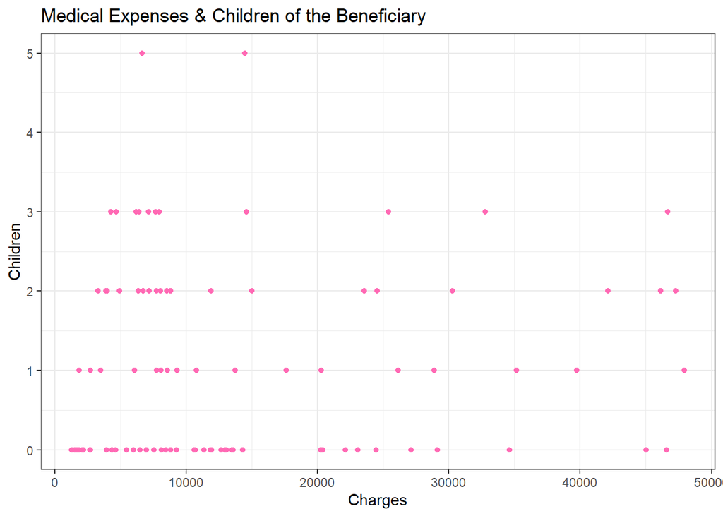

```r
#Scatterplots
#Scatterplot(s) of Charges vs. Number of Children
ggplot(Insurance_Data_Group16,aes(Charges,Children))+
  geom_point(color='hotpink')+
  theme_bw()+
  labs(title="Medical Expenses & Children of the Beneficiary")
```

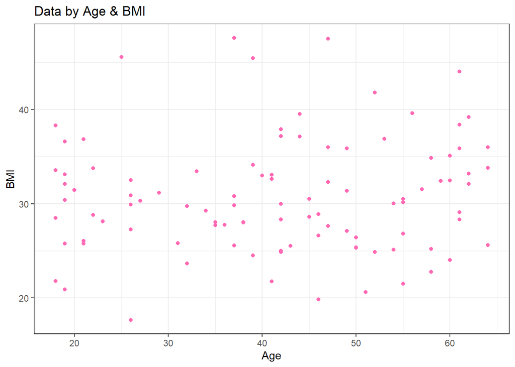

```r
#Scatterplot of Age vs. BMI
ggplot(Insurance_Data_Group16,aes(Age,BMI))+
  geom_point(color='hotpink')+
  theme_bw()+
  labs(title="Data by Age & BMI")
```

# Question 3

Generate a regression equation in the following form:

$$Charges =
\beta_{0}+\beta_{1}*Age+\beta_{2}*BMI+\beta_{3}*Children$$

```r
model<-lm(Charges~Age+BMI+Children, data=Insurance_Data_Group16)
summary(model)
```

```
##
## Call:
## lm(formula = Charges ~ Age + BMI + Children, data = Insurance_Data_Group16)
##
## Residuals:
##    Min     1Q Median     3Q    Max
## -13676  -7061  -4564   7852  29571
##
## Coefficients:
##             Estimate Std. Error t value Pr(>|t|)
## (Intercept) -13486.5     6502.4  -2.074   0.0407 *
## Age            360.6       78.9   4.570 1.45e-05 ***
## BMI            359.1      184.8   1.943   0.0549 .
## Children      1233.0      921.8   1.338   0.1842
## ---
## Signif. codes:  0 '***' 0.001 '**' 0.01 '*' 0.05 '.' 0.1 ' ' 1
##
## Residual standard error: 11070 on 96 degrees of freedom
## Multiple R-squared:  0.2225, Adjusted R-squared:  0.1982
## F-statistic: 9.158 on 3 and 96 DF,  p-value: 2.178e-05
```

```r
coefs <- coefficients(model)
```

also write out the regression cleanly in this document.

```r
cat("Charges =",
    round(coefs[1], 2),
    "+", round(coefs[2], 2), "*Age",
    "+", round(coefs[3], 2), "*BMI",
    "+", round(coefs[4], 2), "*Children", "\n")
```

```
## Charges = -13486.53 + 360.59 *Age + 359.11 *BMI + 1232.99 *Children
```

# Question 4

An eager insurance representative comes back with a potential client. The client is 40, their BMI is 30, and they have one dependent. Using the regression equation above, predict the amount of medical expenses associated with this policy. (Provide a 95% confidence interval as well)

We anticipate the client’s potential medical expenses to be $12,943.56. With a 95% confidence interval, we predict the range to be within $10,718.09 and $15,169.04.

```r
newPrediction<-data.frame(Age=40,
                          BMI=30,
                          Children=1)

prediction <- predict(model, newdata=newPrediction, interval="confidence", level=0.95)
print(prediction)
```

```
##        fit      lwr      upr
## 1 12943.56 10718.09 15169.04
```